# R Notebook

# Pre-processing and visualization

Original code by Kamran Afzali, adapted by Jeanne Racicot

Load packages

```r
library(readr)
library(tidyverse)
library(gridExtra)
library(lmerTest)
library(lme4)
library(glmnet)
library(glmmLasso)
library(MASS)
library(nlme)
library(knitr)
library(kableExtra)
scale_this <- function(x){
  (x - mean(x, na.rm=TRUE)) / sd(x, na.rm=TRUE)
}
```

Load data from prefrontal atlas

```r
data <- read_csv("output_data/dataframe_day2day.csv")
conn_names <- read_csv("output_data/105_connection_names_reversed.csv")
```

Tally

```r
data %>% group_by(subject) %>% tally()
```

```
## # A tibble: 6 × 2
##   subject     n
##     <dbl> <int>
## 1       1    50
## 2       3    50
## 3       5    45
## 4       6    47
## 5       7    40
## 6       8    49
```

```r
by_id <- data %>% group_by(subject)
by_id <- by_id %>%
  mutate(daysFromFirstScan_STD=scale_this(daysFromFirstScan))
data$daysFromFirstScan_STD=by_id$daysFromFirstScan_STD
```

```r
plots=list()

subs=unique(data$subject)
i=1
for (s in subs) {
x=as.numeric(data$daysFromFirstScan[data$subject==s])
y1=as.numeric(as.character(data$PANAS_PA[data$subject==s]))
PosA=rep("PA",length(y1))
y2=as.numeric(as.character(data$PANAS_NA[data$subject==s]))
NegA=rep("NA",length(y2))

Data=as.data.frame(rbind(cbind(day=x,outcome=PosA,value=as.numeric(as.character(y1))),
cbind(day=x,outcome=NegA,value=as.numeric(as.character(y2)))))


Data$day=as.numeric(as.character(Data$day))
plots[[i]]=ggplot( Data, aes(x = day, y = value, group=outcome, color=outcome)) +
  geom_line()+geom_point()+ggtitle(as.character(s))
i=i+1
rm(Data)
}
```

## Outcome plots per subject

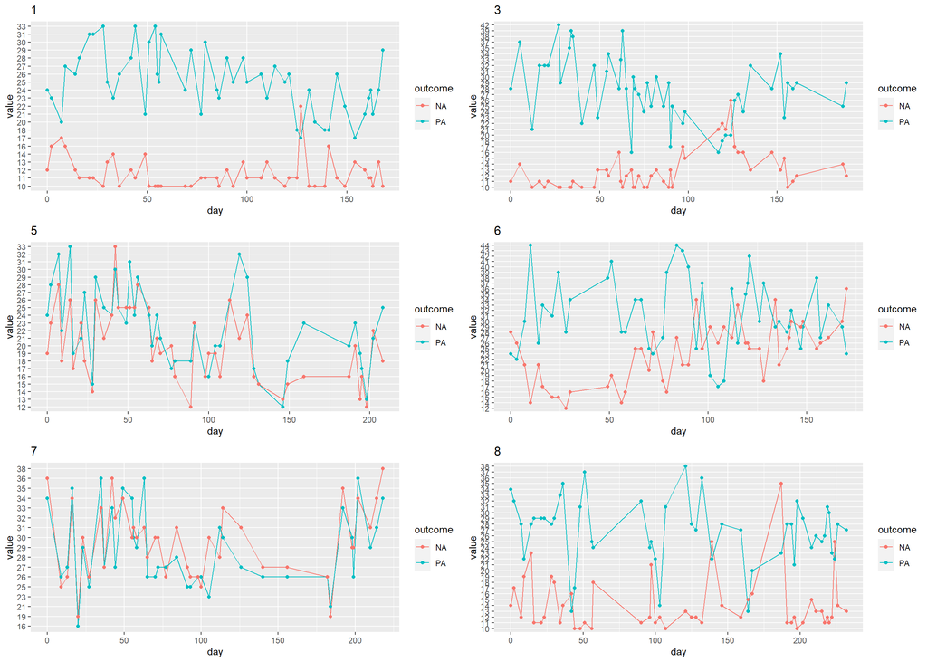

```r
do.call(grid.arrange,plots)
```

## Data pre-processiong, creating BP and WP variables

Between person is the mean of every connection for every session and subject Within person is each connection, centered to 0 (value-mean)

```r
dataML <-by_id %>% summarise(
  C1BP = mean(connection1),
  C2BP = mean(connection2),
  C3BP = mean(connection3),
  C4BP = mean(connection4),
  C5BP = mean(connection5),
  C6BP = mean(connection6),
  C7BP = mean(connection7),
  C8BP = mean(connection8),
  C9BP = mean(connection9),
  C10BP = mean(connection10),
  C11BP = mean(connection11),
  C12BP = mean(connection12),
  C13BP = mean(connection13),
  C14BP = mean(connection14),
  C15BP = mean(connection15),
  C16BP = mean(connection16),
  C17BP = mean(connection17),
  C18BP = mean(connection18),
  C19BP = mean(connection19),
  C20BP = mean(connection20),
  C21BP = mean(connection21),
  C22BP = mean(connection22),
  C23BP = mean(connection23),
  C24BP = mean(connection24),
  C25BP = mean(connection25),
  C26BP = mean(connection26),
  C27BP = mean(connection27),
  C28BP = mean(connection28),
  C29BP = mean(connection29),
  C30BP = mean(connection30),
  C31BP = mean(connection31),
  C32BP = mean(connection32),
  C33BP = mean(connection33),
  C34BP = mean(connection34),
  C35BP = mean(connection35),
  C36BP = mean(connection36),
  C37BP = mean(connection37),
  C38BP = mean(connection38),
  C39BP = mean(connection39),
  C40BP = mean(connection40),
  C41BP = mean(connection41),
  C42BP = mean(connection42),
  C43BP = mean(connection43),
  C44BP = mean(connection44),
  C45BP = mean(connection45),
  C46BP = mean(connection46),
  C47BP = mean(connection47),
  C48BP = mean(connection48),
  C49BP = mean(connection49),
  C50BP = mean(connection50),
  C51BP = mean(connection51),
  C52BP = mean(connection52),
  C53BP = mean(connection53),
  C54BP = mean(connection54),
  C55BP = mean(connection55),
  C56BP = mean(connection56),
  C57BP = mean(connection57),
  C58BP = mean(connection58),
  C59BP = mean(connection59),
  C60BP = mean(connection60),
  C61BP = mean(connection61),
  C62BP = mean(connection62),
  C63BP = mean(connection63),
  C64BP = mean(connection64),
  C65BP = mean(connection65),
  C66BP = mean(connection66),
  C67BP = mean(connection67),
  C68BP = mean(connection68),
  C69BP = mean(connection69),
  C70BP = mean(connection70),
  C71BP = mean(connection71),
  C72BP = mean(connection72),
  C73BP = mean(connection73),
  C74BP = mean(connection74),
  C75BP = mean(connection75),
  C76BP = mean(connection76),
  C77BP = mean(connection77),
  C78BP = mean(connection78),
  C79BP = mean(connection79),
  C80BP = mean(connection80),
  C81BP = mean(connection81),
  C82BP = mean(connection82),
  C83BP = mean(connection83),
  C84BP = mean(connection84),
  C85BP = mean(connection85),
  C86BP = mean(connection86),
  C87BP = mean(connection87),
  C88BP = mean(connection88),
  C89BP = mean(connection89),
  C90BP = mean(connection90),
  C91BP = mean(connection91),
  C92BP = mean(connection92),
  C93BP = mean(connection93),
  C94BP = mean(connection94),
  C95BP = mean(connection95),
  C96BP = mean(connection96),
  C97BP = mean(connection97),
  C98BP = mean(connection98),
  C99BP = mean(connection99),
  C100BP = mean(connection100),
  C101BP = mean(connection101),
  C102BP = mean(connection102),
  C103BP = mean(connection103),
  C104BP = mean(connection104),
  C105BP = mean(connection105)


  ) %>%
  inner_join(data, by = "subject")  %>%
  mutate(C1WP=connection1 -C1BP,
         C2WP=connection2 -C2BP,
         C3WP=connection3 -C3BP,
         C4WP=connection4 -C4BP,
         C5WP=connection5 -C5BP,
         C6WP=connection6 -C6BP,
         C7WP=connection7 -C7BP,
         C8WP=connection8 -C8BP,
         C9WP=connection9 -C9BP,
         C10WP=connection10-C10BP,
         C11WP=connection11-C11BP,
         C12WP=connection12-C12BP,
         C13WP=connection13-C13BP,
         C14WP=connection14-C14BP,
         C15WP=connection15-C15BP,
         C16WP=connection16-C16BP,
         C17WP=connection17-C17BP,
         C18WP=connection18-C18BP,
         C19WP=connection19-C19BP,
         C20WP=connection20-C20BP,
         C21WP=connection21-C21BP,
         C22WP=connection22-C22BP,
         C23WP=connection23-C23BP,
         C24WP=connection24-C24BP,
         C25WP=connection25-C25BP,
         C26WP=connection26-C26BP,
         C27WP=connection27-C27BP,
         C28WP=connection28-C28BP,
         C29WP=connection29-C29BP,
         C30WP=connection30-C30BP,
         C31WP=connection31 -C31BP,
         C32WP=connection32 -C32BP,
         C33WP=connection33 -C33BP,
         C34WP=connection34 -C34BP,
         C35WP=connection35 -C35BP,
         C36WP=connection36 -C36BP,
         C37WP=connection37 -C37BP,
         C38WP=connection38 -C38BP,
         C39WP=connection39 -C39BP,
         C40WP=connection40 -C40BP,
         C41WP=connection41 -C41BP,
         C42WP=connection42 -C42BP,
         C43WP=connection43 -C43BP,
         C44WP=connection44 -C44BP,
         C45WP=connection45 -C45BP,
         C46WP=connection46 -C46BP,
         C47WP=connection47 -C47BP,
         C48WP=connection48 -C48BP,
         C49WP=connection49 -C49BP,
         C50WP=connection50 -C50BP,
         C51WP=connection51 -C51BP,
         C52WP=connection52 -C52BP,
         C53WP=connection53 -C53BP,
         C54WP=connection54 -C54BP,
         C55WP=connection55 -C55BP,
         C56WP=connection56 -C56BP,
         C57WP=connection57 -C57BP,
         C58WP=connection58 -C58BP,
         C59WP=connection59 -C59BP,
         C60WP=connection60 -C60BP,
         C61WP=connection61 -C61BP,
         C62WP=connection62 -C62BP,
         C63WP=connection63 -C63BP,
         C64WP=connection64 -C64BP,
         C65WP=connection65 -C65BP,
         C66WP=connection66 -C66BP,
         C67WP=connection67 -C67BP,
         C68WP=connection68 -C68BP,
         C69WP=connection69 -C69BP,
         C70WP=connection70 -C70BP,
         C71WP=connection71 -C71BP,
         C72WP=connection72 -C72BP,
         C73WP=connection73 -C73BP,
         C74WP=connection74 -C74BP,
         C75WP=connection75 -C75BP,
         C76WP=connection76 -C76BP,
         C77WP=connection77 -C77BP,
         C78WP=connection78 -C78BP,
         C79WP=connection79 -C79BP,
         C80WP=connection80 -C80BP,
         C81WP=connection81 -C81BP,
         C82WP=connection82 -C82BP,
         C83WP=connection83 -C83BP,
         C84WP=connection84 -C84BP,
         C85WP=connection85 -C85BP,
         C86WP=connection86 -C86BP,
         C87WP=connection87 -C87BP,
         C88WP=connection88 -C88BP,
         C89WP=connection89 -C89BP,
         C90WP=connection90 -C90BP,
         C91WP=connection91 -C91BP,
         C92WP=connection92 -C92BP,
         C93WP=connection93 -C93BP,
         C94WP=connection94 -C94BP,
         C95WP=connection95 -C95BP,
         C96WP=connection96 -C96BP,
         C97WP=connection97 -C97BP,
         C98WP=connection98 -C98BP,
         C99WP=connection99 -C99BP,
         C100WP=connection100 -C100BP,
         C101WP=connection101 -C101BP,
         C102WP=connection102 -C102BP,
         C103WP=connection103 -C103BP,
         C104WP=connection104 -C104BP,
         C105WP=connection105 -C105BP
  )
```

# Linear Models

## A note on the massive univariate models

PANAS_PA = fixed intercept (group level mean of PA) + C1WP (effect of connection1 within person) + C1BP (effect of connection1 between person) + daysFromFirstScan_STD (linear effect of time) + 1|subject (random intercept or deviation of the person level mean with respect to the group level mean PA).

PANAS_NA = fixed intercept (group level mean of NA) + C1WP (effect of connection1 within person) + C1BP (effect of connection1 between person) + daysFromFirstScan_STD (linear effect of time) + 1|subject (random intercept or deviation of the person level mean with respect to the group level mean NA).

Alors:  
intercept = group level mean of the dependent variable  
daysFromFirstScan_STD = linear effect of time  
C_X_WP= effect of connection “*X*” within person  
C_X_BP= effect of connection “*X*” between person

## Model for positive affectivity with BP effects

```r
results_PA=c()
for (i in 1:105) {
  vars = paste("C",i,"WP + C",i,"BP",sep= "")
  otherVars <- c("daysFromFirstScan_STD","(1|subject)")
  formList=lapply(vars,function(x) {reformulate(c(otherVars,x),response="PANAS_PA")})
  print(formList)
  res=summary(lapply(formList,lmer,data=dataML)[[1]])$coefficients
  results_PA=rbind(res,results_PA)
}
results_PA=as.data.frame(results_PA)
results_PA$sig=results_PA$`Pr(>|t|)`<0.05
```

FDR correction BP

```r
clean_results_PA = results_PA %>%
  filter(str_detect(row.names(results_PA), 'BP'))%>%
  mutate(pval.adj = p.adjust (`Pr(>|t|)`,"fdr"))%>%
  mutate(conn_names, .before=1)%>%as.data.frame()

clean_results_PA%>% kbl(booktabs = T, linesep = "") %>%
  kable_paper(full_width = F) %>%column_spec(1:9, color = "white", background = case_when(clean_results_PA$pval.adj<0.10~"green",
                                                                                          clean_results_PA$'Pr(>|t|)'<0.05~"gold",
                                                                                          TRUE~"lightgray"))
```

|  | connection_name | Estimate | Std. Error | df | t value | Pr(>\|t\|) | sig | pval.adj |
| --- | --- | --- | --- | --- | --- | --- | --- | --- |
| C105BP | R-rHipp - L-rHipp | 3.8079454 | 23.803012 | 3.971867 | 0.1599775 | 0.8807046 | FALSE | 0.9703078 |
| C104BP | R-rHipp - R-lAmyg | 3.4808957 | 19.247512 | 3.976406 | 0.1808491 | 0.8653291 | FALSE | 0.9703078 |
| C103BP | R-rHipp - L-lAmyg | 2.5784954 | 9.587542 | 4.008369 | 0.2689423 | 0.8012497 | FALSE | 0.9703078 |
| C102BP | R-rHipp - R-mAmyg | -31.4982977 | 18.114828 | 3.939420 | -1.7388130 | 0.1581565 | FALSE | 0.9703078 |
| C101BP | R-rHipp - L-mAmyg | -5.9426673 | 10.676433 | 3.989835 | -0.5566154 | 0.6075319 | FALSE | 0.9703078 |
| C100BP | R-rHipp - R-V5/MT+ | 6.9499033 | 8.889873 | 4.023748 | 0.7817776 | 0.4777896 | FALSE | 0.9703078 |
| C99BP | R-rHipp - R-vId/vIg | 6.1952640 | 8.160070 | 4.009290 | 0.7592170 | 0.4899113 | FALSE | 0.9703078 |
| C98BP | R-rHipp - L-vId/vIg | 3.2572561 | 11.054963 | 4.011208 | 0.2946420 | 0.7828873 | FALSE | 0.9703078 |
| C97BP | R-rHipp - L-A22r | 6.0614310 | 20.977114 | 4.000333 | 0.2889545 | 0.7869719 | FALSE | 0.9703078 |
| C96BP | R-rHipp - R-A22c | 0.2041170 | 11.731329 | 3.997125 | 0.0173993 | 0.9869519 | FALSE | 0.9869519 |
| C95BP | R-rHipp - L-A38m | 26.4378283 | 10.790380 | 4.036356 | 2.4501294 | 0.0698667 | FALSE | 0.9703078 |
| C94BP | R-rHipp - R-A13 | 2.4536799 | 17.383666 | 4.031405 | 0.1411486 | 0.8945251 | FALSE | 0.9703078 |
| C93BP | R-rHipp - L-A11l | 11.8892560 | 8.482178 | 4.003595 | 1.4016750 | 0.2335769 | FALSE | 0.9703078 |
| C92BP | R-rHipp - R-A10m | 8.9241209 | 18.668648 | 4.016715 | 0.4780272 | 0.6574843 | FALSE | 0.9703078 |
| C91BP | L-rHipp - R-lAmyg | -8.8261136 | 16.946500 | 4.007286 | -0.5208222 | 0.6299451 | FALSE | 0.9703078 |
| C90BP | L-rHipp - L-lAmyg | -6.1791330 | 12.936441 | 3.993367 | -0.4776532 | 0.6578660 | FALSE | 0.9703078 |
| C89BP | L-rHipp - R-mAmyg | -3.7988299 | 15.304870 | 3.977776 | -0.2482105 | 0.8162583 | FALSE | 0.9703078 |
| C88BP | L-rHipp - L-mAmyg | -0.5256952 | 10.250158 | 3.986185 | -0.0512865 | 0.9615643 | FALSE | 0.9869519 |
| C87BP | L-rHipp - R-V5/MT+ | 11.1161735 | 9.595354 | 4.039811 | 1.1584954 | 0.3105274 | FALSE | 0.9703078 |
| C86BP | L-rHipp - R-vId/vIg | 4.2088055 | 7.797907 | 4.014542 | 0.5397352 | 0.6179253 | FALSE | 0.9703078 |
| C85BP | L-rHipp - L-vId/vIg | 4.6628207 | 9.565698 | 4.031890 | 0.4874522 | 0.6512558 | FALSE | 0.9703078 |
| C84BP | L-rHipp - L-A22r | 11.1150542 | 18.128061 | 4.027438 | 0.6131408 | 0.5727186 | FALSE | 0.9703078 |
| C83BP | L-rHipp - R-A22c | 1.9923088 | 9.819906 | 4.013005 | 0.2028847 | 0.8490969 | FALSE | 0.9703078 |
| C82BP | L-rHipp - L-A38m | 21.3375485 | 15.878812 | 3.999614 | 1.3437749 | 0.2501903 | FALSE | 0.9703078 |
| C81BP | L-rHipp - R-A13 | 8.9354390 | 20.408400 | 4.023576 | 0.4378314 | 0.6839873 | FALSE | 0.9703078 |
| C80BP | L-rHipp - L-A11l | 10.6352917 | 12.245276 | 3.981993 | 0.8685220 | 0.4343208 | FALSE | 0.9703078 |
| C79BP | L-rHipp - R-A10m | 0.4169349 | 13.367738 | 3.992740 | 0.0311896 | 0.9766151 | FALSE | 0.9869519 |
| C78BP | R-lAmyg - L-lAmyg | -16.0747475 | 15.070149 | 4.013337 | -1.0666615 | 0.3460410 | FALSE | 0.9703078 |
| C77BP | R-lAmyg - R-mAmyg | -32.2180348 | 20.070297 | 3.947979 | -1.6052595 | 0.1846404 | FALSE | 0.9703078 |
| C76BP | R-lAmyg - L-mAmyg | -26.5318097 | 12.516716 | 3.922814 | -2.1197100 | 0.1027334 | FALSE | 0.9703078 |

[output cut: 75 more lines]

FDR correction WP

```r
clean_results_PA = results_PA %>%
  filter(str_detect(row.names(results_PA), 'WP'))%>%
  mutate(pval.adj = p.adjust (`Pr(>|t|)`,"fdr"))%>%
  mutate(conn_names, .before=1)%>%as.data.frame()

clean_results_PA%>% kbl(booktabs = T, linesep = "") %>%
  kable_paper(full_width = F) %>%column_spec(1:9, color = "white", background = case_when(clean_results_PA$pval.adj<0.10~"green",
                                                                                          clean_results_PA$'Pr(>|t|)'<0.05~"gold",
                                                                                          TRUE~"lightgray"))
```

|  | connection_name | Estimate | Std. Error | df | t value | Pr(>\|t\|) | sig | pval.adj |
| --- | --- | --- | --- | --- | --- | --- | --- | --- |
| C105WP | R-rHipp - L-rHipp | -1.0064725 | 1.0486108 | 273.0016 | -0.9598152 | 0.3379975 | FALSE | 0.9205181 |
| C104WP | R-rHipp - R-lAmyg | -1.0660354 | 0.6767101 | 272.9994 | -1.5753205 | 0.1163406 | FALSE | 0.8637252 |
| C103WP | R-rHipp - L-lAmyg | 0.2145547 | 0.6672528 | 272.9920 | 0.3215493 | 0.7480402 | FALSE | 0.9563649 |
| C102WP | R-rHipp - R-mAmyg | 0.2131099 | 0.7879657 | 272.9457 | 0.2704559 | 0.7870140 | FALSE | 0.9681226 |
| C101WP | R-rHipp - L-mAmyg | -0.6330116 | 0.7585533 | 272.9842 | -0.8344985 | 0.4047298 | FALSE | 0.9205181 |
| C100WP | R-rHipp - R-V5/MT+ | -0.3796547 | 0.6681545 | 272.9954 | -0.5682139 | 0.5703568 | FALSE | 0.9398217 |
| C99WP | R-rHipp - R-vId/vIg | -0.2230124 | 0.6521562 | 272.9925 | -0.3419616 | 0.7326429 | FALSE | 0.9497223 |
| C98WP | R-rHipp - L-vId/vIg | -0.5616641 | 0.6539370 | 272.9907 | -0.8588963 | 0.3911512 | FALSE | 0.9205181 |
| C97WP | R-rHipp - L-A22r | -0.2482230 | 0.7194412 | 272.9915 | -0.3450219 | 0.7303436 | FALSE | 0.9497223 |
| C96WP | R-rHipp - R-A22c | 0.0129349 | 0.6595106 | 272.9930 | 0.0196128 | 0.9843666 | FALSE | 0.9994722 |
| C95WP | R-rHipp - L-A38m | -0.6589761 | 0.7550872 | 273.0356 | -0.8727152 | 0.3835851 | FALSE | 0.9205181 |
| C94WP | R-rHipp - R-A13 | 0.8068716 | 0.6683219 | 272.9860 | 1.2073098 | 0.2283579 | FALSE | 0.9205181 |
| C93WP | R-rHipp - L-A11l | 1.0420979 | 0.6614427 | 272.9869 | 1.5754922 | 0.1163010 | FALSE | 0.8637252 |
| C92WP | R-rHipp - R-A10m | 0.0605881 | 0.7280108 | 272.9934 | 0.0832242 | 0.9337343 | FALSE | 0.9804210 |
| C91WP | L-rHipp - R-lAmyg | -0.9025733 | 0.7015624 | 272.9811 | -1.2865190 | 0.1993520 | FALSE | 0.9205181 |
| C90WP | L-rHipp - L-lAmyg | -0.0004367 | 0.6595435 | 272.9937 | -0.0006621 | 0.9994722 | FALSE | 0.9994722 |
| C89WP | L-rHipp - R-mAmyg | 0.0908208 | 0.8006528 | 272.9956 | 0.1134334 | 0.9097703 | FALSE | 0.9773885 |
| C88WP | L-rHipp - L-mAmyg | -0.9632789 | 0.8100425 | 272.9954 | -1.1891709 | 0.2354057 | FALSE | 0.9205181 |
| C87WP | L-rHipp - R-V5/MT+ | -0.7467246 | 0.6541766 | 272.9987 | -1.1414724 | 0.2546736 | FALSE | 0.9205181 |
| C86WP | L-rHipp - R-vId/vIg | -1.2774510 | 0.6656285 | 272.9933 | -1.9191652 | 0.0560059 | FALSE | 0.8637252 |
| C85WP | L-rHipp - L-vId/vIg | -1.2645906 | 0.6489103 | 272.9886 | -1.9487911 | 0.0523447 | FALSE | 0.8637252 |
| C84WP | L-rHipp - L-A22r | -0.7981771 | 0.7067836 | 272.9904 | -1.1293090 | 0.2597588 | FALSE | 0.9205181 |
| C83WP | L-rHipp - R-A22c | -1.3065720 | 0.6817646 | 272.9913 | -1.9164563 | 0.0563511 | FALSE | 0.8637252 |
| C82WP | L-rHipp - L-A38m | -0.2980745 | 0.7813115 | 272.9990 | -0.3815054 | 0.7031250 | FALSE | 0.9398217 |
| C81WP | L-rHipp - R-A13 | -0.0068835 | 0.6749658 | 272.9877 | -0.0101984 | 0.9918705 | FALSE | 0.9994722 |
| C80WP | L-rHipp - L-A11l | -0.4837428 | 0.6899873 | 272.9957 | -0.7010895 | 0.4838444 | FALSE | 0.9237029 |
| C79WP | L-rHipp - R-A10m | -1.5133247 | 0.7132837 | 272.9945 | -2.1216307 | 0.0347697 | TRUE | 0.8637252 |
| C78WP | R-lAmyg - L-lAmyg | -0.5934590 | 0.6208897 | 273.0067 | -0.9558203 | 0.3400086 | FALSE | 0.9205181 |
| C77WP | R-lAmyg - R-mAmyg | -1.1033388 | 0.7139143 | 272.9530 | -1.5454778 | 0.1233893 | FALSE | 0.8637252 |
| C76WP | R-lAmyg - L-mAmyg | -0.6798411 | 0.6793251 | 272.9250 | -1.0007596 | 0.3178295 | FALSE | 0.9205181 |

[output cut: 75 more lines]

## Model for negative affectivity with BP effects

```r
results_NA=c()
for (i in 1:105) {
  vars = paste("C",i,"WP + C",i,"BP",sep= "")
  otherVars <- c("daysFromFirstScan_STD","(1|subject)")
  formList=lapply(vars,function(x) {reformulate(c(otherVars,x),response="PANAS_NA")})
  print(formList)
  res=summary(lapply(formList,lmer,data=dataML)[[1]])$coefficients
  results_NA=rbind(res,results_NA)
}
results_NA=as.data.frame(results_NA)
results_NA$sig=results_NA$`Pr(>|t|)`<0.05
```

FDR correction BP

```r
clean_results_NA = results_NA %>%
  filter(str_detect(row.names(results_NA), 'BP'))%>%
  mutate(pval.adj = p.adjust (`Pr(>|t|)`,"fdr"))%>%
  mutate(conn_names, .before=1)%>%as.data.frame()

clean_results_NA%>% kbl(booktabs = T, linesep = "") %>%
  kable_paper(full_width = F) %>%column_spec(1:9, color = "white", background = case_when(clean_results_NA$pval.adj<0.10~"green",
                                                                                          clean_results_NA$'Pr(>|t|)'<0.05~"gold",
                                                                                          TRUE~"lightgray"))
```

|  | connection_name | Estimate | Std. Error | df | t value | Pr(>\|t\|) | sig | pval.adj |
| --- | --- | --- | --- | --- | --- | --- | --- | --- |
| C105BP | R-rHipp - L-rHipp | -5.4236343 | 55.410852 | 3.994280 | -0.0978804 | 0.9267423 | FALSE | 0.9625380 |
| C104BP | R-rHipp - R-lAmyg | 42.6573169 | 39.497123 | 3.993697 | 1.0800107 | 0.3409977 | FALSE | 0.5314369 |
| C103BP | R-rHipp - L-lAmyg | 41.9323161 | 7.987172 | 4.020998 | 5.2499579 | 0.0062067 | TRUE | 0.2389686 |
| C102BP | R-rHipp - R-mAmyg | 13.4982651 | 55.431624 | 3.997466 | 0.2435120 | 0.8195949 | FALSE | 0.9058680 |
| C101BP | R-rHipp - L-mAmyg | 30.7279537 | 20.645831 | 4.001482 | 1.4883369 | 0.2108608 | FALSE | 0.4160258 |
| C100BP | R-rHipp - R-V5/MT+ | 39.0694756 | 10.402285 | 4.023017 | 3.7558552 | 0.0196417 | TRUE | 0.2389686 |
| C99BP | R-rHipp - R-vId/vIg | 34.6789827 | 10.455187 | 4.011932 | 3.3169165 | 0.0293320 | TRUE | 0.2502303 |
| C98BP | R-rHipp - L-vId/vIg | 44.7969831 | 13.049402 | 4.013798 | 3.4328763 | 0.0263222 | TRUE | 0.2502303 |
| C97BP | R-rHipp - L-A22r | 87.3812185 | 22.556511 | 3.999139 | 3.8738802 | 0.0179415 | TRUE | 0.2389686 |
| C96BP | R-rHipp - R-A22c | 44.3619408 | 15.783664 | 3.997713 | 2.8106238 | 0.0483179 | TRUE | 0.2808615 |
| C95BP | R-rHipp - L-A38m | 14.2741284 | 38.931754 | 3.997148 | 0.3666449 | 0.7324678 | FALSE | 0.8359687 |
| C94BP | R-rHipp - R-A13 | 65.1865432 | 23.884000 | 4.016786 | 2.7292976 | 0.0522425 | FALSE | 0.2808615 |
| C93BP | R-rHipp - L-A11l | 37.4468125 | 15.070108 | 4.006354 | 2.4848403 | 0.0677592 | FALSE | 0.2808615 |
| C92BP | R-rHipp - R-A10m | 52.8643595 | 35.820231 | 4.004190 | 1.4758241 | 0.2139561 | FALSE | 0.4160258 |
| C91BP | L-rHipp - R-lAmyg | 49.1251088 | 32.375853 | 4.005020 | 1.5173379 | 0.2036957 | FALSE | 0.4160258 |
| C90BP | L-rHipp - L-lAmyg | 45.9735535 | 20.598167 | 3.991591 | 2.2319244 | 0.0895614 | FALSE | 0.2938735 |
| C89BP | L-rHipp - R-mAmyg | 29.8826968 | 32.560414 | 3.996201 | 0.9177616 | 0.4107203 | FALSE | 0.5989671 |
| C88BP | L-rHipp - L-mAmyg | 31.7858368 | 17.725250 | 3.996734 | 1.7932518 | 0.1474501 | FALSE | 0.3600525 |
| C87BP | L-rHipp - R-V5/MT+ | 39.3591974 | 16.518456 | 4.010887 | 2.3827407 | 0.0755880 | FALSE | 0.2834549 |
| C86BP | L-rHipp - R-vId/vIg | 33.9507791 | 7.923319 | 4.026612 | 4.2849189 | 0.0126155 | TRUE | 0.2389686 |
| C85BP | L-rHipp - L-vId/vIg | 40.4796239 | 10.566117 | 4.032572 | 3.8310786 | 0.0183230 | TRUE | 0.2389686 |
| C84BP | L-rHipp - L-A22r | 77.3903848 | 20.874171 | 4.023844 | 3.7074710 | 0.0204830 | TRUE | 0.2389686 |
| C83BP | L-rHipp - R-A22c | 36.3597655 | 13.921561 | 4.011782 | 2.6117593 | 0.0591349 | FALSE | 0.2808615 |
| C82BP | L-rHipp - L-A38m | -16.4323441 | 43.631020 | 3.997584 | -0.3766207 | 0.7255931 | FALSE | 0.8359687 |
| C81BP | L-rHipp - R-A13 | 74.7463444 | 30.834247 | 4.013678 | 2.4241339 | 0.0722215 | FALSE | 0.2808615 |
| C80BP | L-rHipp - L-A11l | 29.8643710 | 27.175028 | 3.997805 | 1.0989638 | 0.3335167 | FALSE | 0.5305947 |
| C79BP | L-rHipp - R-A10m | 28.9387782 | 27.457458 | 3.998867 | 1.0539496 | 0.3513747 | FALSE | 0.5347007 |
| C78BP | R-lAmyg - L-lAmyg | 12.8690519 | 39.081523 | 3.997075 | 0.3292874 | 0.7584705 | FALSE | 0.8563377 |
| C77BP | R-lAmyg - R-mAmyg | -3.2720281 | 59.828870 | 3.996809 | -0.0546898 | 0.9590102 | FALSE | 0.9776317 |
| C76BP | R-lAmyg - L-mAmyg | 7.3534185 | 42.279952 | 3.997498 | 0.1739221 | 0.8703790 | FALSE | 0.9231292 |

[output cut: 75 more lines]

FDR correction WP

```r
clean_results_NA = results_NA %>%
  filter(str_detect(row.names(results_NA), 'WP'))%>%
  mutate(pval.adj = p.adjust (`Pr(>|t|)`,"fdr"))%>%
  mutate(conn_names, .before=1)%>%as.data.frame()


clean_results_NA%>% kbl(booktabs = T, linesep = "") %>%
  kable_paper(full_width = F) %>%column_spec(1:9, color = "white", background = case_when(clean_results_NA$pval.adj<0.10~"green",
                                                                                          clean_results_NA$'Pr(>|t|)'<0.05~"gold",
                                                                                          TRUE~"lightgray"))
```

|  | connection_name | Estimate | Std. Error | df | t value | Pr(>\|t\|) | sig | pval.adj |
| --- | --- | --- | --- | --- | --- | --- | --- | --- |
| C105WP | R-rHipp - L-rHipp | 0.4828136 | 0.8636499 | 272.9980 | 0.5590386 | 0.5765937 | FALSE | 0.9991054 |
| C104WP | R-rHipp - R-lAmyg | -0.2762412 | 0.5590018 | 272.9974 | -0.4941687 | 0.6215844 | FALSE | 0.9991054 |
| C103WP | R-rHipp - L-lAmyg | -0.0061275 | 0.5490429 | 273.0050 | -0.0111603 | 0.9911037 | FALSE | 0.9991609 |
| C102WP | R-rHipp - R-mAmyg | -0.7022487 | 0.6469168 | 272.9979 | -1.0855317 | 0.2786438 | FALSE | 0.9991054 |
| C101WP | R-rHipp - L-mAmyg | -0.1348219 | 0.6247910 | 273.0004 | -0.2157871 | 0.8293148 | FALSE | 0.9991054 |
| C100WP | R-rHipp - R-V5/MT+ | -0.0373324 | 0.5500010 | 273.0088 | -0.0678769 | 0.9459333 | FALSE | 0.9991054 |
| C99WP | R-rHipp - R-vId/vIg | -1.0169517 | 0.5330932 | 273.0050 | -1.9076432 | 0.0574865 | FALSE | 0.9991054 |
| C98WP | R-rHipp - L-vId/vIg | -0.7338011 | 0.5368769 | 273.0038 | -1.3667959 | 0.1728138 | FALSE | 0.9991054 |
| C97WP | R-rHipp - L-A22r | 0.4045763 | 0.5915019 | 272.9939 | 0.6839814 | 0.4945671 | FALSE | 0.9991054 |
| C96WP | R-rHipp - R-A22c | -0.4785005 | 0.5418015 | 272.9962 | -0.8831656 | 0.3779238 | FALSE | 0.9991054 |
| C95WP | R-rHipp - L-A38m | 0.2844993 | 0.6218561 | 272.9971 | 0.4575003 | 0.6476754 | FALSE | 0.9991054 |
| C94WP | R-rHipp - R-A13 | 0.2314444 | 0.5511058 | 273.0004 | 0.4199637 | 0.6748423 | FALSE | 0.9991054 |
| C93WP | R-rHipp - L-A11l | -0.2392139 | 0.5464344 | 273.0026 | -0.4377724 | 0.6618974 | FALSE | 0.9991054 |
| C92WP | R-rHipp - R-A10m | -0.4012107 | 0.5984426 | 272.9999 | -0.6704248 | 0.5031538 | FALSE | 0.9991054 |
| C91WP | L-rHipp - R-lAmyg | -0.0732483 | 0.5788919 | 273.0001 | -0.1265320 | 0.8994040 | FALSE | 0.9991054 |
| C90WP | L-rHipp - L-lAmyg | -0.4364477 | 0.5419609 | 272.9917 | -0.8053121 | 0.4213404 | FALSE | 0.9991054 |
| C89WP | L-rHipp - R-mAmyg | -0.1999155 | 0.6585955 | 272.9989 | -0.3035482 | 0.7617033 | FALSE | 0.9991054 |
| C88WP | L-rHipp - L-mAmyg | 0.8978537 | 0.6659262 | 272.9988 | 1.3482780 | 0.1786865 | FALSE | 0.9991054 |
| C87WP | L-rHipp - R-V5/MT+ | -0.3089423 | 0.5391452 | 273.0014 | -0.5730224 | 0.5671012 | FALSE | 0.9991054 |
| C86WP | L-rHipp - R-vId/vIg | -0.5539160 | 0.5502611 | 273.0124 | -1.0066421 | 0.3149981 | FALSE | 0.9991054 |
| C85WP | L-rHipp - L-vId/vIg | -0.2935831 | 0.5372525 | 273.0081 | -0.5464528 | 0.5852010 | FALSE | 0.9991054 |
| C84WP | L-rHipp - L-A22r | 0.4691280 | 0.5821244 | 273.0048 | 0.8058897 | 0.4210078 | FALSE | 0.9991054 |
| C83WP | L-rHipp - R-A22c | -0.1997714 | 0.5645086 | 273.0043 | -0.3538855 | 0.7236979 | FALSE | 0.9991054 |
| C82WP | L-rHipp - L-A38m | 0.4834537 | 0.6422871 | 272.9975 | 0.7527066 | 0.4522748 | FALSE | 0.9991054 |
| C81WP | L-rHipp - R-A13 | 0.1651867 | 0.5551934 | 273.0030 | 0.2975301 | 0.7662881 | FALSE | 0.9991054 |
| C80WP | L-rHipp - L-A11l | 0.1225718 | 0.5681095 | 272.9996 | 0.2157539 | 0.8293407 | FALSE | 0.9991054 |
| C79WP | L-rHipp - R-A10m | -0.2921096 | 0.5913664 | 272.9991 | -0.4939570 | 0.6217337 | FALSE | 0.9991054 |
| C78WP | R-lAmyg - L-lAmyg | -0.0617549 | 0.5116481 | 272.9964 | -0.1206979 | 0.9040191 | FALSE | 0.9991054 |
| C77WP | R-lAmyg - R-mAmyg | -0.0084571 | 0.5898737 | 272.9972 | -0.0143372 | 0.9885714 | FALSE | 0.9991609 |
| C76WP | R-lAmyg - L-mAmyg | -0.0005893 | 0.5598648 | 272.9977 | -0.0010526 | 0.9991609 | FALSE | 0.9991609 |

[output cut: 75 more lines]